# 01-File-System

## Linux file system

- The Linux file system adheres to the `File Hierarchy Structure (FHS)`, which organizes directories and files in a standardized manner, naming them after their function or content.

## Linux Directory Structure

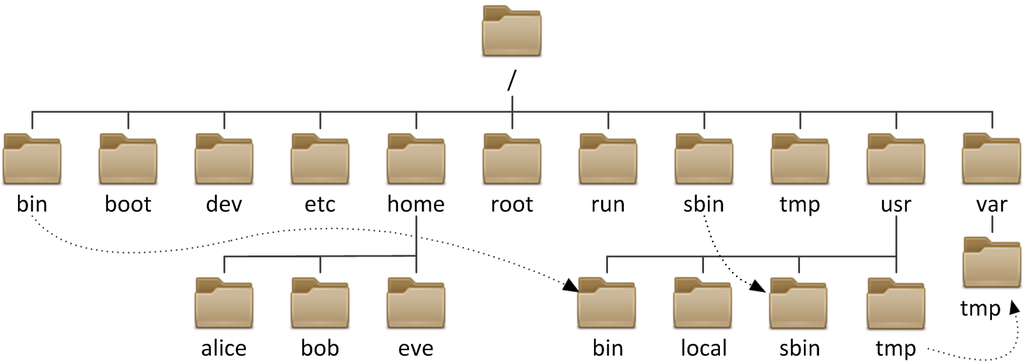

1. `/` (**Root**): This is the top-level directory of the file system. All other directories are nested beneath this one.
2. `/bin` (**User Binaries**): Contains essential user command binaries (programs) that are needed for the system to boot up and run.
   - `/sbin`: Stands for **"system binaries"** and contains essential system administration binaries. These commands are **not intended for regular users** but for the root and system maintenance purposes.
3. `/etc` (Configuration Files): Houses system-wide configuration files and directories.
   - It typically contains the configuration files for all the software on your system.
4. `/home` (User Home Directories): Holds the personal directories of all users who have an account on the system, except for the root user.
5. `/boot`: Contains files needed to **start up the system**, including the `Linux kernel`, an initial RAM disk image (for drivers needed at startup), and the bootloader.
   - In simple terms, this is where the files necessary for booting the system are stored.
6. `/opt` (**Optional Software**): Generally contains third-party software that doesn't conform to the standard system structure.
   - Software inside `/opt` is static and does not change frequently.
7. `/tmp` (**Temporary Files**): Used to store temporary files created by system and user applications.
8. `/var` (**Variable Files**): Intended for files that are expected to grow over time. This includes log files, spool files, and cached data.
9. `/dev`: This is a special directory which contains device nodes.
   - It's a way for the Linux kernel to provide access to the hardware of the system via these files.
   - For example, `/dev/sda` typically represents the first SATA drive.
10. `/usr` (**User Binaries and Libraries**): Contains user commands, their libraries, documentation, etc. It is the second major hierarchy after the root.
    - `/usr/local`: This hierarchy is for use by the system administrator when installing software locally. It should mimic the structure of `/usr`. These are usually software or programs that are installed from source, or manually by the sysadmin.